# Non-linear regression and some tools for doing it

Sam Taylor

17 June, 2021

The aim here is to show what non-linear regression does and show some tools that help with success in applying it.

A key disclaimer is that when you are using non-linear models, your data might be worse than you think, so some parameters may not identify as non-zero or estimate stably.

Another useful hint is that when you are using complex (and even simple) functions, you will have a better chance of understanding why they fit (or don’t) if you play around with your function of choice. Going between trying to fit models and seeing what range is sensible for parameters by just trying out the maths is important for getting to grips with how sensitive each parameter is. It will help you establish what makes sense to ‘fix’ versus ‘estimate’.

I haven’t managed to fit mixed-effects into this demo’, but they can be an important way of handling replication in non-linear models, where a ‘replicate’ commonly consists of a data series from one source.

## Let’s start by reviewing a basic linear model

$y = mx + c$ is obviously linear We can make a function that evaluates it

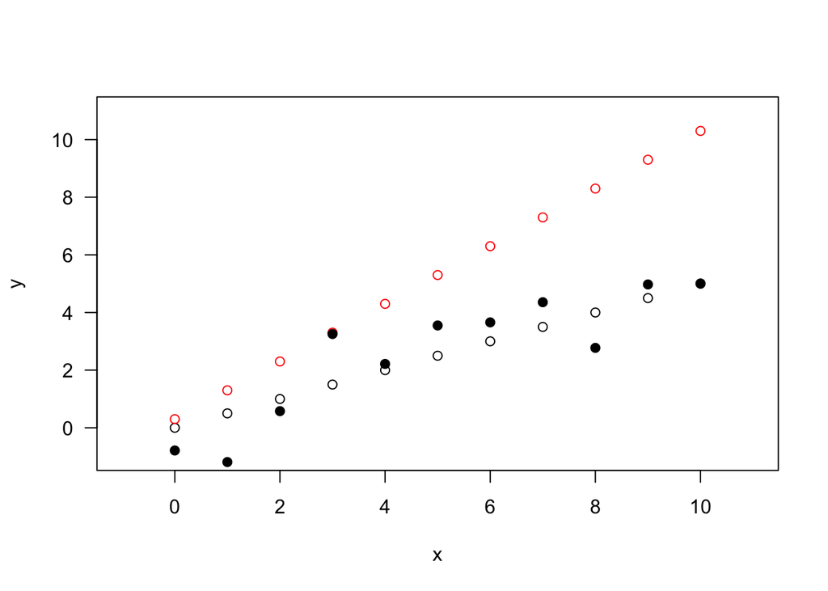

```r
sl <- function(m, c, x){
  m * x + c
}

sl1 <- sl(m = 0.5,
          c = 0,
          x = c(0:10)
          )

plot(sl1 ~ c(0:10),
     xlab = "x",
     ylab= "y",
     xlim = c(-1, 11),
     ylim = c(-1, 11),
     las = 1
     )

#trying some different parameters
sl2 <- sl(m = 1,
          c = 0.3,
          x = c(0:10)
          )
points(sl2 ~ c(0:10), col = "red")

#use sl() with rnorm() to generate a model dataset
sl1df <- data.frame(
  x = c(0:10),
  y = rnorm(11, sl1)
)
points(y ~ x, pch = 19, data = sl1df)
```

`lm()` will fit linear models

```r
lm.sl1 <- lm(y ~ x, data = sl1df)
#look at coefficients and their difference from 0
summary(lm.sl1)
```

```
##
## Call:
## lm(formula = y ~ x, data = sl1df)
##
## Residuals:
##      Min       1Q   Median       3Q      Max
## -1.54939 -0.47136  0.07135  0.55585  1.83366
##
## Coefficients:
##             Estimate Std. Error t value Pr(>|t|)
## (Intercept)  -0.3218     0.5943  -0.541 0.601335
## x             0.5805     0.1004   5.779 0.000266 ***
## ---
## Signif. codes:  0 '***' 0.001 '**' 0.01 '*' 0.05 '.' 0.1 ' ' 1
##
## Residual standard error: 1.054 on 9 degrees of freedom
## Multiple R-squared:  0.7877, Adjusted R-squared:  0.7641
## F-statistic: 33.39 on 1 and 9 DF,  p-value: 0.0002665
```

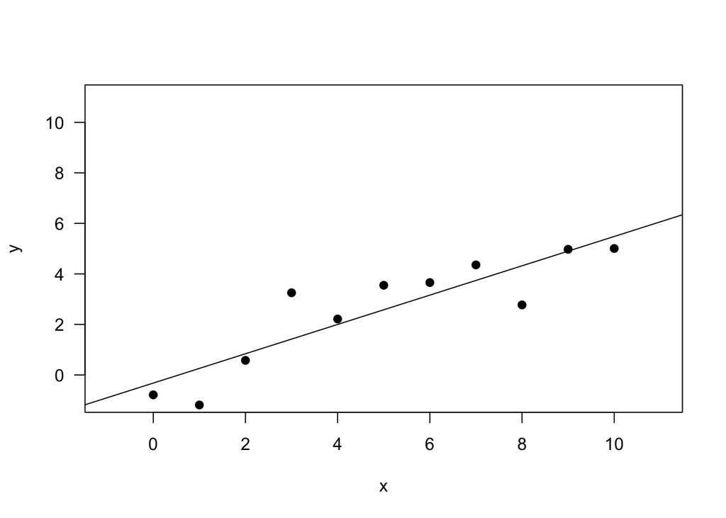

```r
#add the best fit line to the plot
plot(y ~ x,
      xlab = "x",
      ylab= "y",
      xlim = c(-1, 11),
      ylim = c(-1, 11),
      pch = 19,
      data = sl1df,
      las = 1
      )
abline(lm.sl1)
```

Note that the coefficients here don’t exactly match the input values:  
$m = 0.5$ but `x` $\neq0.5$ (`x` is the slope of the regression)  
$c = 0$ but `(Intercept)` $\neq0$  
From a statistical standpoint, these estimates are consistent with the inputs: e.g. `(Intercept)` is not significantly different from 0

```r
sl1df_ext <- data.frame(
  x = rep(c(0:10), 3),
  y = rnorm(33, rep(sl1, 3))
)

lm.sl1_ext <- lm(y ~ x, data = sl1df_ext)

summary(lm.sl1_ext)
```

```
##
## Call:
## lm(formula = y ~ x, data = sl1df_ext)
##
## Residuals:
##      Min       1Q   Median       3Q      Max
## -1.29282 -0.49549 -0.03752  0.28635  1.95474
##
## Coefficients:
##             Estimate Std. Error t value Pr(>|t|)
## (Intercept)  0.65920    0.24995   2.637   0.0129 *
## x            0.37502    0.04225   8.876  5.1e-10 ***
## ---
## Signif. codes:  0 '***' 0.001 '**' 0.01 '*' 0.05 '.' 0.1 ' ' 1
##
## Residual standard error: 0.7675 on 31 degrees of freedom
## Multiple R-squared:  0.7176, Adjusted R-squared:  0.7085
## F-statistic: 78.79 on 1 and 31 DF,  p-value: 5.095e-10
```

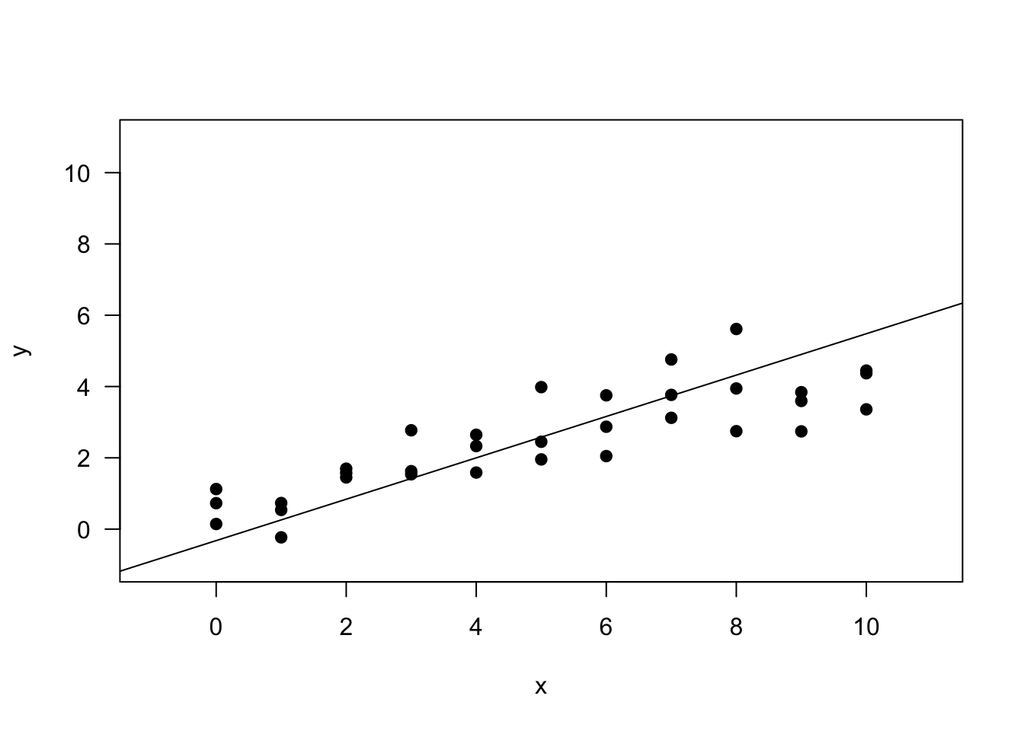

```r
plot(y ~ x,
     xlab = "x",
     ylab= "y",
     xlim = c(-1, 11),
     ylim = c(-1, 11),
     pch = 19,
     data = sl1df_ext,
     las = 1
)
abline(lm.sl1)
```

This is hopefully not news to you, but a useful reminder when tearing your hair over failure to fit non-linear model parameters - issues with non-linear models usually stem from not having enough data to get good estimates of parameters.

## When is a model non-linear?

`lm()` deals with any function of the form $y = ax + bx + cx$ and with transformations, and extend to models with $\log$ or exponents e.g. $y = ax + bx + cx^2$

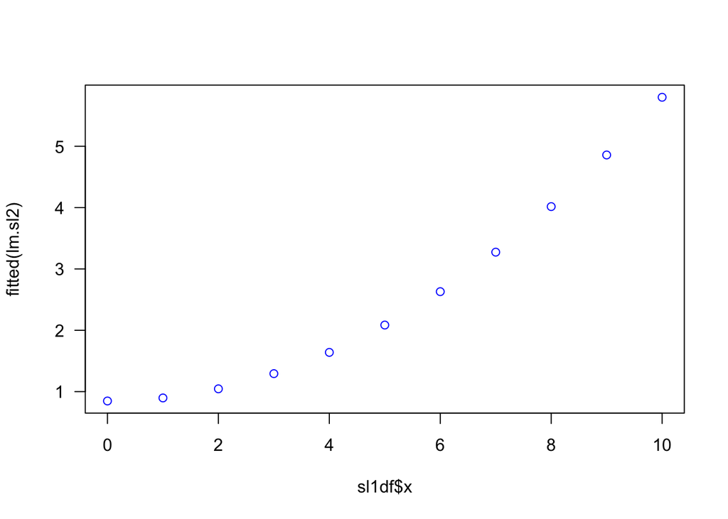

```r
sl1df$x2 <- sl1df$x^2
lm.sl2 <- lm(y ~ x2, data = sl1df)
plot(fitted(lm.sl2) ~ sl1df$x,
     col = "blue",
     las = 1
)
```

This is clearly not a ‘linear equation’

Similarly, empirical, *wiggly* polynomial functions, can also be fit using non-parametric `loess()` or parametric GAM methods (GAM is a whole topic unto itself).

‘Non-linear models’ are thus subtly different from ‘non-linear equations’ :-o  
‘Non-linear models’ are usually pre-defined and chosen for their form/ theoretical underpinning.

An ecologist might model a saturating function for Holling predation responses $C = \frac{\alpha N^n}{1 + \alpha tN^n}$.

A biochemist might be interested in Michaelis-Menten models for enzyme kinetics $v = V_{max}\frac{[S]}{K_M + [S]}$.

These are both non-linear models because they are not expressed as $y = ax + bx + cx$.

The old school method was to linearise models like these before analysis. e.g., the Lineweaver-Burk linearisation of the Michaelis-Menten equation: $\frac {1}{v}=\frac {K_M}{V_{max}}\cdot \frac {1}{[S]}+\frac {1}{V_{max}}$ horrible in this case because you end up with compound variables ($y = \frac{1}{V}, m = \frac{K_M}{V_{max}}$). These old methods are often robust alternatives to non-linear regression, but in some cases they may be so robust they will provide parameter estimates even when the data is of dubious quality.

##Let’s fit a non-linear model! In my world of plant physiology, a relatively commonly used model for the response of photosynthesis to light is the non-rectangular hyperbola $A = \frac{\phi Q + A_{sat} - \sqrt{(\phi Q + A_{sat})^2 - (4\theta\phi QA_{sat})} }{2\theta} - R_d$.  
This isn’t mechanistic, but its parameters align with biological expectations

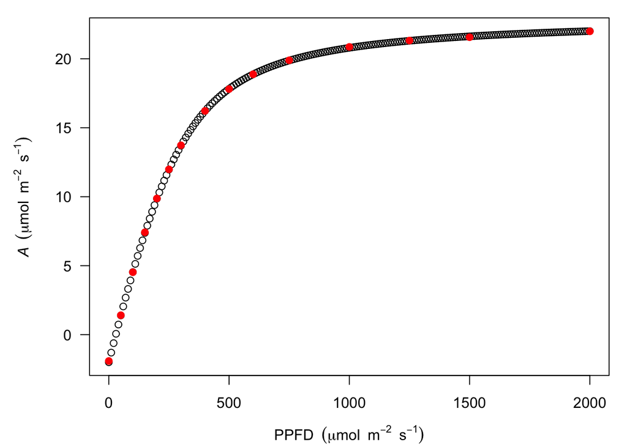

```r
#create a function that evaluates the non-rectangular hyperbola
AQ.form <- function(phi, Asat, theta, Rd, Q){
  (phi * Q + Asat - sqrt((phi * Q + Asat)^2 - (4 * theta * phi * Q * Asat))) /
      (2 * theta) - Rd
}

#reasonable theoretical values for a C3 plant
c3 <- AQ.form(phi = 0.07,
              Asat = 25,
              theta = 0.8,
              Rd = 2,
              Q = seq(0, 2000, 10)
              )
par(mar = c(4, 5, 1, 1))
plot(c3 ~ seq(0, 2000, 10),
     ylab = expression(italic(A)~~(mu*mol~~m^-2~~s^-1)),
     xlab = expression(PPFD~~(mu*mol~~m^-2~~s^-1)),
     las = 1
     )

#most protocols would look more like this
Qexpt <- c(2000, 1500, 1250, 1000, 750, 600, 500, 400,
           300, 250, 200, 150, 100, 50, 0
           )
c3ideal <- AQ.form(phi = 0.07,
                  Asat = 25,
                  theta = 0.8,
                  Rd = 2,
                  Q = Qexpt
)
c3expt <- data.frame(
  A = rnorm(n = length(Qexpt), mean = c3ideal, sd = 1/20),
  Q = Qexpt
)
points(A ~ Q, data = c3expt, pch = 19, col = "red")
```

The most convenient way to fit this function uses non-linear least squares `nls` Several settings are worth noting here:  
-`start =` this names vector/list holds the all-critical initial values if it is missing the model will fail because it can’t find all the parameters it needs for its first interation  
-`algorithm =` is the optimisation algorithm used to find minima for multiple parameters. The default is Gauss-Newton, which does not work with this model because it is unbounded so can explore negative parameter values that result in non-real values for this function. `"port"` enables setting bounds.  
-`lower =` actually setting the bounds for all of the parameters  
-`trace = TRUE` is a handy diagnostic if you’re struggling to guess good starting values because it prints each round of values tried by the algorithm. You can use it to identify starting values that might need bounds setting, or to home in on values that will work well.

```r
c3m1 <- nls(
  formula = A ~
    (phi * Q + Asat - sqrt((phi * Q + Asat)^2 - (4 * theta * phi * Q * Asat))) /
      (2 * theta) - Rd,
  data = c3expt,
  start = c(phi = 0.05, Asat = 20, theta = 0.5, Rd = 1.5),
  algorithm = "port",
  lower = c(phi = 0, Asat = 0, theta = 0, Rd = 0),
  trace = TRUE
)
```

```
##   0:     183.76233: 0.0500000  20.0000 0.500000  1.50000
##   1:     15.228415: 0.0624312  22.3814 0.947675 0.481552
##   2:    0.59424392: 0.0682477  24.4464 0.859699  1.94872
##   3:   0.018133488: 0.0694027  24.8627 0.810694  1.93848
##   4:  0.0065088717: 0.0694700  24.9044 0.803765  1.93521
##   5:  0.0065061999: 0.0694650  24.9044 0.803717  1.93493
##   6:  0.0065061998: 0.0694649  24.9044 0.803717  1.93493
##   7:  0.0065061998: 0.0694649  24.9044 0.803717  1.93493
```

```r
summary(c3m1)
```

```
##
## Formula: A ~ (phi * Q + Asat - sqrt((phi * Q + Asat)^2 - (4 * theta *
##     phi * Q * Asat)))/(2 * theta) - Rd
##
## Parameters:
##        Estimate Std. Error t value Pr(>|t|)
## phi   6.946e-02  3.906e-04  177.83  < 2e-16 ***
## Asat  2.490e+01  5.011e-02  497.00  < 2e-16 ***
## theta 8.037e-01  3.730e-03  215.50  < 2e-16 ***
## Rd    1.935e+00  2.893e-02   66.88 1.04e-15 ***
## ---
## Signif. codes:  0 '***' 0.001 '**' 0.01 '*' 0.05 '.' 0.1 ' ' 1
##
## Residual standard error: 0.03439 on 11 degrees of freedom
##
## Algorithm "port", convergence message: both X-convergence and relative convergence (5)
```

This is still least squares with parametric assumptions, so you should check distribution of residual and normality.

Residuals checks are really important to ensure your model is roughly the right shape.

In this example, they’re both adequate because the data were derived as a normal distribution around the theoretical model.

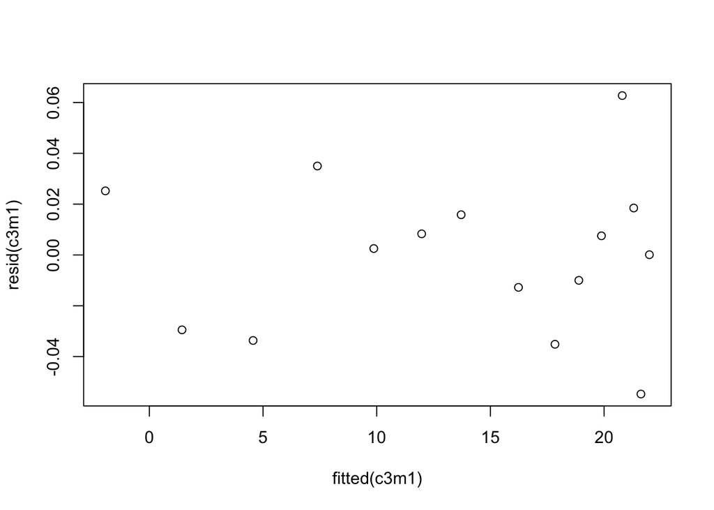

```r
plot(resid(c3m1) ~ fitted(c3m1))
```

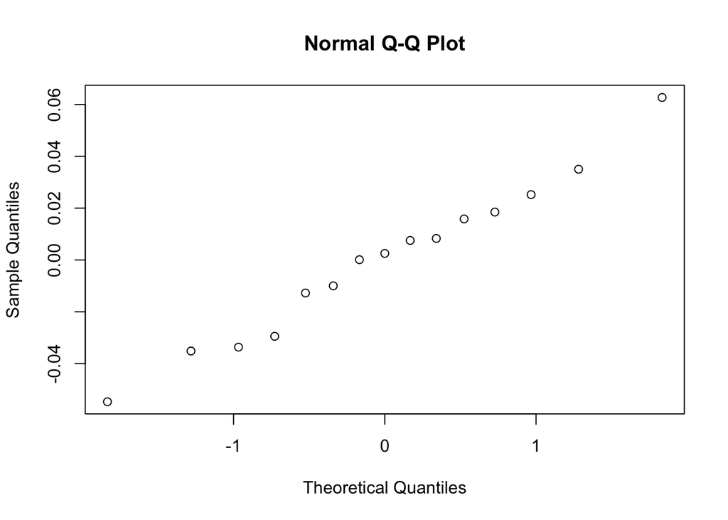

```r
qqnorm(resid(c3m1))
```

It’s a bit of a misuse of the data, since the values are *A* versus [CO$_2$] but we can illustrate how to handle multiple curves with the R’s ‘CO2’ data.

Excuse my use of lattice rather than ggplot…

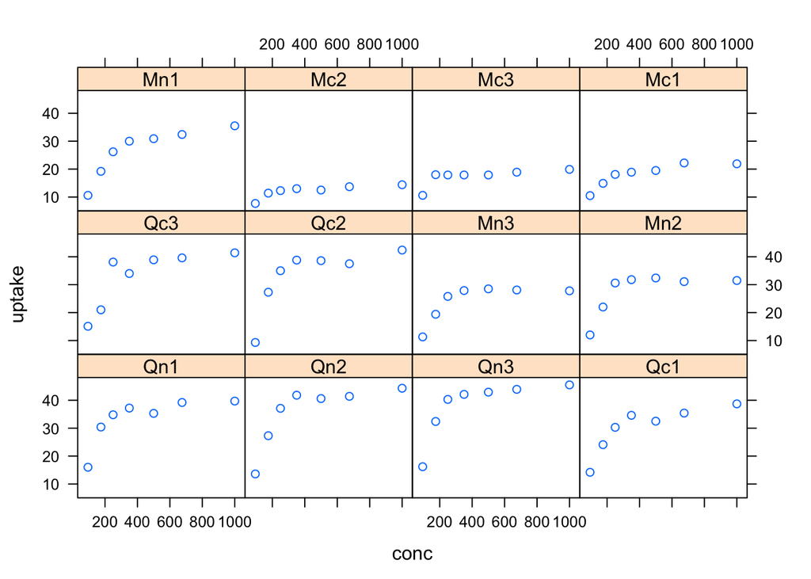

```r
library(lattice)
xyplot(uptake ~ conc | Plant, data = CO2)
```

You can get a quick evaluation of parameters for every plant using `nlsList()` from `nlme` provided you don’t need bounds… (so the example I was building died right here - a more manual approach is needed for that one… probably, build a function that fits the nls and reports coefficients, then loop or `tapply` it).

Points to note  
- it’s `model`, not `formula`, and there’s grouping using `|` - I’m also using a built in `SSasympOff()` function - akin to AQ.form above (I’ll add formula here later) and tweaked to get running nicely

```r
library(nlme)
CO2m1 <- nlsList(
  model = uptake ~ SSasympOff(conc, Asym, lrc, c0) | Plant,
  data = CO2,
  start = c(Asym = 30, lrc = -4.5, c0 = 52)
)
```

Convenient output with stats

```r
summary(CO2m1)
```

```
## Call:
##   Model: uptake ~ SSasympOff(conc, Asym, lrc, c0) | Plant
##    Data: CO2
##
## Coefficients:
##    Asym
##     Estimate Std. Error  t value     Pr(>|t|)
## Qn1 38.13977  0.9911148 38.48169 1.991990e-06
## Qn2 42.87169  1.0932089 39.21638 2.583953e-06
## Qn3 44.22800  1.0241029 43.18706 1.809264e-07
## Qc1 36.42874  1.1941594 30.50576 1.140085e-05
## Qc3 40.68373  1.2480923 32.59673 1.424635e-04
## Qc2 39.81950  1.0167249 39.16447 2.692304e-06
## Mn3 28.48286  1.0624246 26.80930 1.066434e-06
## Mn2 32.12827  1.0174826 31.57624 3.488786e-06
## Mn1 34.08482  1.3400596 25.43530 4.199333e-06
## Mc2 13.55519  1.0506404 12.90184 4.385886e-06
## Mc3 18.53506  0.8363371 22.16219 1.461563e-06
## Mc1 21.78723  1.4113318 15.43735 5.756870e-06
##    lrc
##      Estimate Std. Error    t value     Pr(>|t|)
## Qn1 -4.380644  0.2208028 -19.839619 2.789830e-05
## Qn2 -4.665729  0.1581312 -29.505433 8.036962e-06
## Qn3 -4.486118  0.1698748 -26.408377 1.291542e-06
## Qc1 -4.861743  0.2124536 -22.883790 3.574865e-05
## Qc3 -4.945224  0.1794899 -27.551544 2.755565e-04
## Qc2 -4.463838  0.1564976 -28.523374 9.531807e-06
## Mn3 -4.591568  0.2690656 -17.064866 6.469560e-06
## Mn2 -4.466159  0.2330265 -19.165888 2.548156e-05
## Mn1 -5.064581  0.2069979 -24.466818 4.902553e-06
## Mc2 -4.560837  0.8205919  -5.557985 1.242261e-04
## Mc3 -3.465154  1.2239549  -2.831113 4.548635e-03
## Mc1 -5.142254  0.4475241 -11.490451 1.865741e-05
##    c0
##      Estimate Std. Error    t value     Pr(>|t|)
## Qn1  51.22339  12.621415  4.0584503 0.0117881705
## Qn2  55.85812   9.998223  5.5868047 0.0051398910
## Qn3  54.64957   9.814189  5.5684251 0.0006120973
## Qc1  31.07523  18.988562  1.6365238 0.2228656247
## Qc3  35.08849  15.994855  2.1937360 0.3930978982
## Qc2  72.09421   6.924937 10.4108111 0.0005089520
## Mn3  46.97175  18.133617  2.5903133 0.0092921369
## Mn2  56.03854  13.055059  4.2924772 0.0079487725
## Mn1  36.40792  19.079715  1.9082002 0.0606748414
## Mc2  13.05797  78.005843  0.1673973 0.6806034305
## Mc3  67.84888  33.737248  2.0110971 0.0150825859
## Mc1 -20.39979  62.466416 -0.3265722 0.5367855446
##
## Residual standard error: 1.79822 on 48 degrees of freedom
```

You can plot validations simply

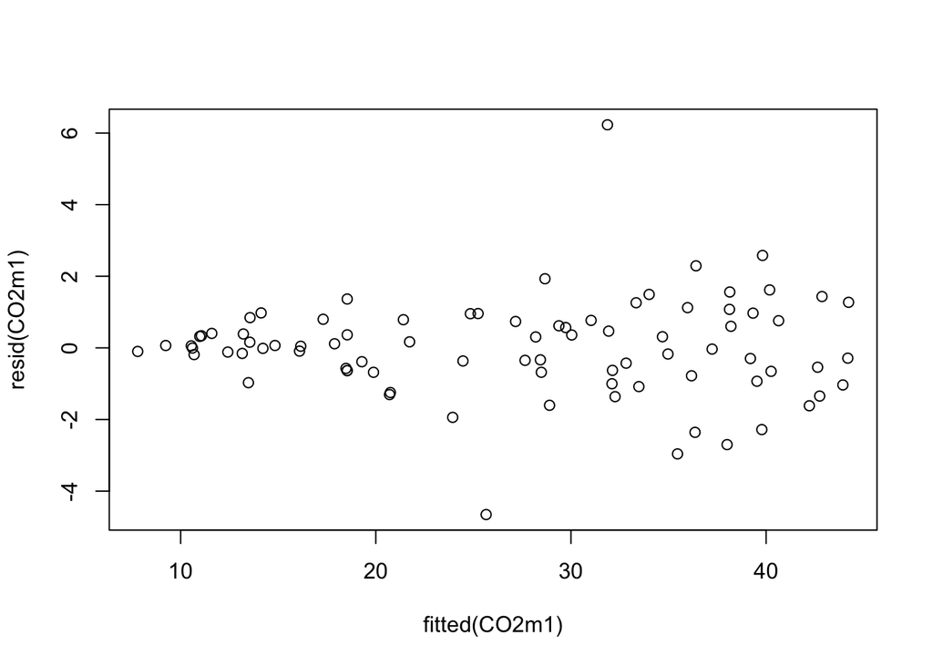

```r
plot(resid(CO2m1)~fitted(CO2m1))
```

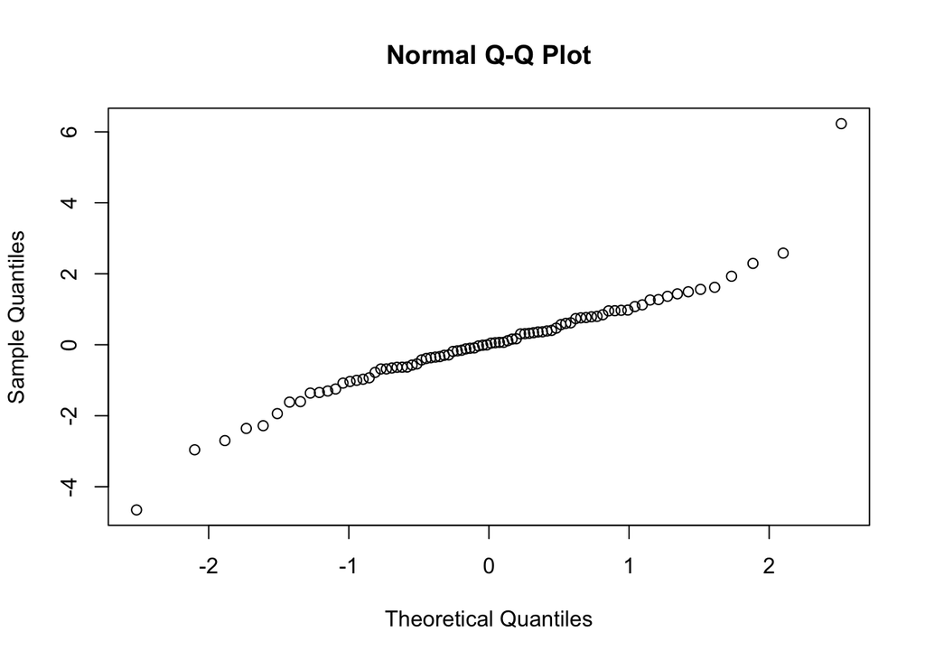

```r
qqnorm(resid(CO2m1))
```

or more usefully

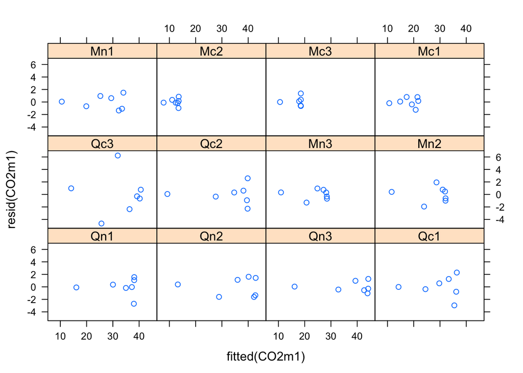

```r
xyplot(resid(CO2m1) ~ fitted(CO2m1) | CO2$Plant)
```

and there are tools for more detailed visualisation

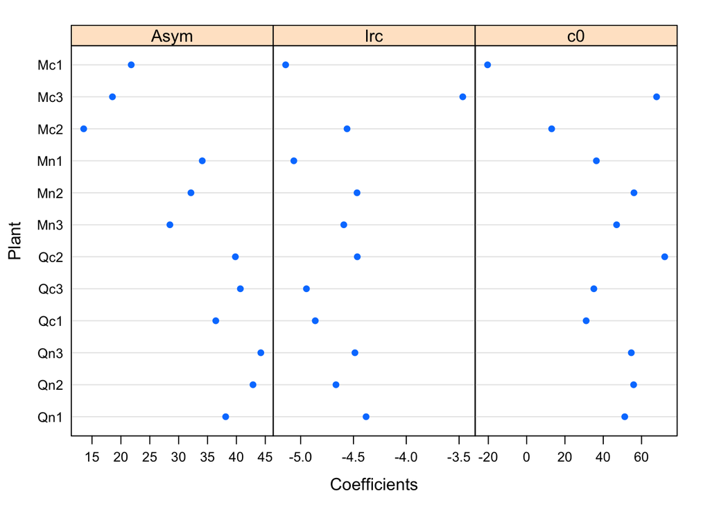

```r
plot(coef(CO2m1))
```

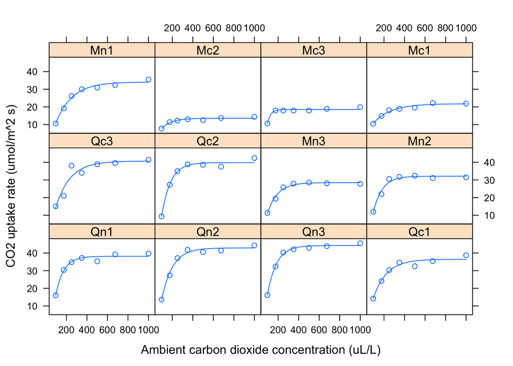

```r
plot(augPred(CO2m1))
```

The story of `nlme()` (mixed effects) will need to wait for another time… And, if you feel really brave, and none of these pre-built functions work there’s always the option of building your own by using `optim()` to do parameter searches while minimising sums of squares…